# Scalable Record Linkage with FlexRL

```r
library(FlexRL)
```

`FlexRL` is a package proposing flexible probabilistic **R**ecord **L**inkage with diagnostic tools for downstream inference on linked data. The record linkage algorithm `StEM()` uses a **St**ochastic **E**xpectation **M**aximisation approach to combine 2 data sources and outputs the set of records referring to the same entities.

More details on the [record linkage methodology](https://doi.org/10.1093/jrsssc/qlaf016); on the [false discovery proportion estimation](https://doi.org/10.1002/sim.70292); and on the potential risks of downstream inference on linked data (Robach et al., in preparation).

Several other algorithms for record linkage are available in R. The `link_with_*()` wrappers of FlexRL run them through one common interface, so that the same diagnostics and false discovery proportion (FDP) estimators apply to all of them: `link_with_FlexRL()`, `link_with_BRL()`, `link_with_fastLink()`, `link_with_multilink()`, `link_with_reclin2()`, `link_with_diyar()`, `link_with_fedmatch()`. Each wrapper takes the two encoded sources and a named list of arguments forwarded to the underlying package, and returns a list with `idxA`, `idxB` (row indices of the linked records in dataA and dataB) and `LinkScore` (the linkage scores, `NULL` when the package does not return any).

This vignette runs these wrappers on the same pipeline for: - a regional subset of the [NLTCS](https://www.icpsr.umich.edu/web/NACDA/studies/9681/versions/V5) data (1982 and 1994 waves) - the [SHIW](https://www.bancaditalia.it/statistiche/tematiche/indagini-famiglie-imprese/bilanci-famiglie/distribuzione-microdati/index.html) data (2012 and 2014 waves) data with and without regional blocking

## One pipeline for all the wrappers

```r
peakRAMNew <- function(...){
  # Capture R expressions or function calls
  args <- c(as.list(match.call(expand.dots = FALSE)$`...`), NULL)
  Function <- sapply(args, function(e) paste0(deparse(e), collapse = ""))
  Function <- sapply(Function, function(e) gsub(" ", "", e))
  # Initialize containers for output
  numfunc <- length(args)
  totaltime <- vector("numeric", numfunc)
  RAMused <- vector("numeric", numfunc)
  RAMpeak <- vector("numeric", numfunc)
  i <- 1
  for(arg in args){
    # Reset garbage collector and save baseline
    start <- gc(verbose = FALSE, reset = TRUE)
    # Evaluate regular and anonymous functions
    evalTime <- system.time(result <- eval.parent(arg))
    if(inherits(result, "function")){
      evalTime <- system.time(output <- result())
      rm(result)
    }else{
      output <- result
      rm(result)
    }
    # Call garbage collector and save post-eval
    end <- gc(verbose = FALSE, reset = FALSE)
    rm(output)
    # Calculate total and peak RAM used
    totaltime[i] <- as.numeric(evalTime["elapsed"])
    get_column_mb = function(object, before_column) {
      ind = which(colnames(object) == before_column)
      stopifnot(colnames(object)[ind+1] == "(Mb)")
      if (length(ind) == 0) {
        stop("No value found for that column")
      }
      # need to ref index and not colname because duplicated colnames for (Mb)
      object[2, ind + 1]
    }
    RAMused[i] <- get_column_mb(end, "used")- get_column_mb(start, "used")
    RAMpeak[i] <- get_column_mb(end, "max used") - get_column_mb(start, "max used")
    i <- i + 1
  }
  data.frame("Function_Call" = Function,
             "Elapsed_Time_sec" = totaltime,
             "Total_RAM_Used_MiB" = RAMused,
             "Peak_RAM_Used_MiB" = RAMpeak,
             row.names = 1:numfunc)
}

wrapper_args <- function(method, prep_data, ...) {
  PIVs <- names(prep_data$PIVs_config)
  args <- c(...)
  switch(method,
         FlexRL    = c(list(data = prep_data, threads = 4),
                       args[intersect(names(args), names(formals(FlexRL::StEM)))]),
         BRL       = c(list(flds = PIVs, types = rep("bi", length(PIVs)), nIter = 1000),
                       args[intersect(names(args), c(names(formals(BRL::compareRecords)), names(formals(BRL::bipartiteGibbs))))]),
         fastLink  = c(list(varnames = PIVs, tol.em = 1e-06, threshold.match = 0.5, return.all = TRUE, n.cores = 4),
                       args[intersect(names(args), names(formals(fastLink::fastLink)))]),
         multilink = c(list(types = rep("bi", length(PIVs)), breaks = stats::setNames(as.list(rep(NA, length(PIVs))), PIVs),
                            duplicates = c(0, 0), n_iter = 1000, max_cc_size = 50),
                       args[intersect(names(args), c(names(formals(multilink::create_comparison_data)),
                                                     names(formals(multilink::reduce_comparison_data)),
                                                     names(formals(multilink::specify_prior)),
                                                     names(formals(multilink::gibbs_sampler)),
                                                     names(formals(multilink::find_bayes_estimate)),
                                                     names(formals(multilink::relabel_bayes_estimate))))]),
         reclin2   = c(list(on = PIVs, formula = stats::as.formula(paste("~", paste(PIVs, collapse = "+"))),
                            type = "mpost", add = TRUE, variable = "selected", score = "mpost", threshold = 0.5),
                       args[intersect(names(args), c(names(formals(reclin2::pair)),
                                                     names(formals(reclin2::compare_pairs)),
                                                     names(formals(reclin2::problink_em)),
                                                     names(formals(stats::predict)),
                                                     names(formals(reclin2::select_threshold))))]),
         diyar     = c(list(probabilistic = TRUE, return_weights = TRUE),
                       args[intersect(names(args), c(names(formals(diyar::prob_score_range)),
                                                     names(formals(diyar::links_wf_probabilistic))))]),
         fedmatch  = c(list(by = PIVs, match_type = "multivar", unique_key_1 = "unique_key_A",
                            unique_key_2 = "unique_key_B", nthread = 4,
                            multivar_settings = fedmatch::build_multivar_settings(
                              compare_type = rep("indicator", length(PIVs)),
                              wgts = rep(1 / length(PIVs), length(PIVs)))),
                       args[intersect(names(args), names(formals(fedmatch::merge_plus)))])
  )
}

# unix::rlimit_as(20e9) # may be needed on some OS

run_wrapper <- function(method, prep_data, arguments) {
  PIVs <- names(prep_data$PIVs_config)
  link_with <- get(paste0("link_with_", method), envir = asNamespace("FlexRL"))
  if (method == "diyar") {
    prep_data$encodedA <- prep_data$encodedA[, c(PIVs, "local_id", "source")]
    prep_data$encodedB <- prep_data$encodedB[, c(PIVs, "local_id", "source")]
  }
  if (Sys.info()["sysname"] == "Darwin") {
    tryCatch(link_with(prep_data$encodedA, prep_data$encodedB, arguments),
           error = function(e) {
             if (grepl("cannot allocate|memory|bad_alloc|too large|long vectors", conditionMessage(e), ignore.case = TRUE)) {
               message(method, ": memory error (", conditionMessage(e), "), results reported as NA")
               return(NULL)
             }
             stop(e)
           })
  } else if (Sys.info()["sysname"] %in% c("Linux","Windows")) {
      tryCatch(callr::r(function(link_with, A, B, arguments) {link_with(A, B, arguments)},
                      args = list(link_with = link_with, A = prep_data$encodedA,
                                  B = prep_data$encodedB, arguments = arguments)),
           error = function(e) {
             if (grepl("cannot allocate|memory|bad_alloc|too large|long vectors|crashed or was killed|signal 9|SIGKILL",
               conditionMessage(e), ignore.case = TRUE)) {
               message(method, ": memory error (", conditionMessage(e), "), results reported as NA")
               return(NULL)
             }
             stop(e)
           })
  } else {
    print("Unknown Operating System.")
  }
}

evaluate_linkage <- function(fit, true_pairs, threshold = 0.5) {
  if (is.null(fit)) return(rep(NA_real_, 5))
  delta_result <- data.frame(idxA = fit$idxA, idxB = fit$idxB)
  if (!is.null(fit$LinkScore)) delta_result <- delta_result[fit$LinkScore > threshold, , drop = FALSE]
  linked_pairs   <- do.call(paste, c(delta_result, list(sep = "_")))
  true_positive  <- length(intersect(linked_pairs, true_pairs))
  false_positive <- length(setdiff(linked_pairs, true_pairs))
  false_negative <- length(setdiff(true_pairs, linked_pairs))
  c(TP = true_positive, FP = false_positive, FN = false_negative,
    sensitivity = true_positive / (true_positive + false_negative),
    FDP = false_positive / (true_positive + false_positive))
}

results_rows <- c("TP               ", "FP               ", "FN               ",
                  "sensitivity      ", "FDP              ", "est. FDP score   ",
                  "est. FDP* score  ", "est. FDP* synth  ", "max SMD          ",
                  "min support IoU  ", "max MMD          ", "time (secs)      ",
                  "memory (Mb)      ")

methods <- c("BRL", "multilink", "fastLink", "reclin2", "diyar", "fedmatch", "FlexRL")

run_all_wrappers <- function(prep_data, variables_type, methods, FDP_estimation = TRUE,
                             maxIter4CV = 2, n_repeats = 3, ...) {
  args <- list(...)
  op <- options()
  on.exit(options(op))
  PIVs <- names(prep_data$PIVs_config)
  true_pairs <- do.call(paste, c(prep_data$true_pairs, list(sep = "_")))
  df_results <- data.frame(matrix(NA, nrow = length(results_rows), ncol = 0))
  rownames(df_results) <- results_rows

  t0 <- Sys.time()
  MeM <- peakRAMNew(naive_fit <- naive_linkage(PIVs = PIVs, encodedA = prep_data$encodedA, encodedB = prep_data$encodedB))
  elapsed <- as.numeric(Sys.time() - t0, units = "secs")
  df_results[1:5, "Naive"] <- evaluate_linkage(list(idxA = naive_fit[[1]], idxB = naive_fit[[2]]), true_pairs)
  df_results[12,"Naive"] <- elapsed
  df_results[13, "Naive"] <- MeM$Peak_RAM_Used_MiB

  for (method in methods) {
    arguments <- wrapper_args(method, prep_data, args)

    t0 <- Sys.time()
    MeM <- peakRAMNew(fit <- run_wrapper(method, prep_data, arguments))
    elapsed <- as.numeric(Sys.time() - t0, units = "secs")
    df_results[1:5, method] <- evaluate_linkage(fit, true_pairs)
    if (is.null(fit) || length(fit$idxA) == 0) next

    encodedA <- prep_data$encodedA
    encodedB <- prep_data$encodedB
    if (method == "diyar") {
      encodedA <- encodedA[, c(PIVs, "local_id", "source")]
      encodedB <- encodedB[, c(PIVs, "local_id", "source")]
    }

    diag <- do.call(RL_diagnostics, c(list(fit, encodedA, encodedB, PIVs, variables_type, PIVs,
                                           true_pairs = prep_data$true_pairs, FDP_estimation = FDP_estimation,
                                           RL_method = method, data = prep_data, maxIter4CV = maxIter4CV, n_repeats = n_repeats),
                                      arguments))
    if (FDP_estimation) {
      df_results[6, method] <- diag$FDP_measures$curve$RL_FDP_score[1]
      df_results[7, method] <- diag$FDP_measures$curve$augmRL_FDP_score[1]
      df_results[8, method] <- diag$FDP_measures$curve$augmRL_FDP_synth[1]
    }
    df_results[9,  method] <- max(diag$discrepancy_measures[1, grep("smd", names(diag$discrepancy_measures))])
    df_results[10, method] <- min(diag$discrepancy_measures[1, grep("iou", names(diag$discrepancy_measures))])
    df_results[11, method] <- max(diag$discrepancy_measures[1, grep("mmd", names(diag$discrepancy_measures))])

    df_results[12, method] <- elapsed
    df_results[13, method] <- MeM$Peak_RAM_Used_MiB
  }
  df_results
}
```

We will fill a table of results throughout the vignette, gathering for each record linkage method: linkage performance, data quality diagnostics: FDP estimation, measures of divergence of linked data from sources.

## Regional subset of the NLTCS data

We use 4 **P**artially **I**dentifying **V**ariable**s** to link the records: sex, birth month and birth year are `stable`, the state code may change over time but we cannot model these changes so we set this variable as `flexible`.

```r
df1982 <- read.csv("ex-reg-NLTCS-82.csv", row.names = 1)
df1994 <- read.csv("ex-reg-NLTCS-94.csv", row.names = 1)

PIVs_config <- list(
  SEX       = list(dynamics = "stable",   bound_mistakes = c(0.10, 0.10), fix_mistakes = c(NA, NA)),
  DOB_MONTH = list(dynamics = "stable",   bound_mistakes = c(0.10, 0.10), fix_mistakes = c(NA, NA)),
  DOB_YEAR  = list(dynamics = "stable",   bound_mistakes = c(0.10, 0.10), fix_mistakes = c(NA, NA)),
  STATE     = list(dynamics = "flexible", bound_mistakes = c(NA, NA),     fix_mistakes = c(NA, NA)))

PIVs_type <- list(SEX = FALSE, DOB_MONTH = TRUE, DOB_YEAR = TRUE, STATE = FALSE)
```

`prepare_data()` removes the records for which the linking variables are outside of the common support, checks that PIVs are not strongly associated with each other (which may degrade record linkage performance), maps PIV values to natural numbers and encodes missing values as 0. The StEM algorithm denotes the smallest source as `A` and the largest as `B`. The true pairs are known from the identifier ID (they are indexed on the rows of `encodedA` and `encodedB`, after the support restriction).

```r
prep_data <- prepare_data(df1982, df1994, "1982", "1994", PIVs_config, same_mistakes = TRUE, uniq_id = "ID")
```

```
#> '1982' is the larger source, saved as B; '1994' saved as A.
```

```r
c(n_A = nrow(prep_data$encodedA), n_B = nrow(prep_data$encodedB), n_links = nrow(prep_data$true_pairs))
```

```
#>     n_A     n_B n_links
#>     491     901     332
```

```r
prep_data$n_values
```

```
#>       SEX DOB_MONTH  DOB_YEAR     STATE
#>         2        12        28         9
```

```r
df_results_NLTCS <- run_all_wrappers(prep_data, PIVs_type, methods)
```

```r
cat("Record Linkage\n")
```

```
#> Record Linkage
```

```r
knitr::kable(df_results_NLTCS[1:5, ], digits = 2, align=rep('c', ncol(df_results_NLTCS)))
```

|  | Naive | BRL | multilink | fastLink | reclin2 | diyar | fedmatch | FlexRL |
| --- | --- | --- | --- | --- | --- | --- | --- | --- |
| TP | 320.00 | 211.00 | 221.00 | 265.00 | 320.00 | 126.00 | 266.00 | 224.00 |
| FP | 163.00 | 15.00 | 26.00 | 78.00 | 163.00 | 5.00 | 223.00 | 28.00 |
| FN | 12.00 | 121.00 | 111.00 | 67.00 | 12.00 | 206.00 | 66.00 | 108.00 |
| sensitivity | 0.96 | 0.64 | 0.67 | 0.80 | 0.96 | 0.38 | 0.80 | 0.67 |
| FDP | 0.34 | 0.07 | 0.11 | 0.23 | 0.34 | 0.04 | 0.46 | 0.11 |

```r
cat("FDP estimation\n")
```

```
#> FDP estimation
```

```r
knitr::kable(df_results_NLTCS[6:8, ], digits = 2, align=rep('c', ncol(df_results_NLTCS)))
```

|  | Naive | BRL | multilink | fastLink | reclin2 | diyar | fedmatch | FlexRL |
| --- | --- | --- | --- | --- | --- | --- | --- | --- |
| est. FDP score | NA | 0.15 | NaN | 0.30 | 0.49 | NaN | 0.07 | 0.16 |
| est. FDP* score | NA | 0.17 | NaN | 0.31 | NA | NaN | 0.07 | 0.18 |
| est. FDP* synth | NA | 0.08 | 0.22 | 0.44 | NA | 0.03 | 0.13 | 0.16 |

```r
cat("Linked divergence\n")
```

```
#> Linked divergence
```

```r
knitr::kable(df_results_NLTCS[9:11, ], digits = 2, align=rep('c', ncol(df_results_NLTCS)))
```

|  | Naive | BRL | multilink | fastLink | reclin2 | diyar | fedmatch | FlexRL |
| --- | --- | --- | --- | --- | --- | --- | --- | --- |
| max SMD | NA | 0.15 | 0.13 | 0.14 | 0.18 | 0.43 | 0.11 | 0.18 |
| min support IoU | NA | 0.88 | 0.88 | 0.88 | 0.88 | 0.88 | 0.88 | 0.88 |
| max MMD | NA | 0.01 | 0.01 | 0.02 | 0.02 | 0.03 | 0.01 | 0.02 |

```r
cat("Computational time and memory\n")
```

```
#> Computational time and memory
```

```r
knitr::kable(df_results_NLTCS[12:13, ], digits = 2, align=rep('c', ncol(df_results_NLTCS)))
```

|  | Naive | BRL | multilink | fastLink | reclin2 | diyar | fedmatch | FlexRL |
| --- | --- | --- | --- | --- | --- | --- | --- | --- |
| time (secs) | 0.23 | 5.8 | 165 | 4.2 | 0.36 | 3 | 2.6 | 7.3 |
| memory (Mb) | 2.50 | 85.0 | 385 | 273.1 | 155.50 | 117 | 105.5 | 109.3 |

## Full SHIW data

We use 5 **P**artially **I**dentifying **V**ariable**s** to link the records: birth year, sex, birth region are `stable`, marital status and occupation are `flexible`. The occupation is built by combining the working status and the branch of activity together as one PIV. We create such variable because the high association level between working status and branch of activity may damage the record linkage performance.

```r
df2012 <- comp[comp$ANNO == 2012, var_of_interest]
df2014 <- comp[comp$ANNO == 2014, var_of_interest]
df2012 <- df2012[!df2012$ID %in% df2012$ID[duplicated(df2012$ID)], ]
df2014 <- df2014[!df2014$ID %in% df2014$ID[duplicated(df2014$ID)], ]
rownames(df2012) <- 1:nrow(df2012)
rownames(df2014) <- 1:nrow(df2014)

PIVs_config <- list(
  ANASC          = list(dynamics = "stable", bound_mistakes = c(0.10, 0.10), fix_mistakes = c(NA, NA)),
  SESSO          = list(dynamics = "stable", bound_mistakes = c(0.10, 0.10), fix_mistakes = c(NA, NA)),
  STACIV         = list(dynamics = "flexible", bound_mistakes = c(NA, NA), fix_mistakes = c(NA, NA)),
  NASCREG        = list(dynamics = "stable", bound_mistakes = c(0.10, 0.10), fix_mistakes = c(NA, NA)),
  SETTP11QUALP10 = list(dynamics = "flexible", bound_mistakes = c(NA, NA), fix_mistakes = c(NA, NA)))

PIVs_type <- list(ANASCI = TRUE, SESSO = FALSE, STACIV = FALSE, NASCREG = FALSE, SETTP11QUALP10 = FALSE)

PIVs_config_full <- c(PIVs_config,
  list(IREG = list(dynamics = "flexible", bound_mistakes = c(NA, NA), fix_mistakes = c(NA, NA))))
PIVs_type_full <- c(PIVs_type, IREG = FALSE)

prep_data_full <- prepare_data(df2012, df2014, "2012", "2014", PIVs_config_full, same_mistakes = TRUE, uniq_id = "ID")
```

```
#> '2012' is the larger source, saved as B; '2014' saved as A.
```

```r
true_pairs_full <- do.call(paste, c(prep_data_full$true_pairs, list(sep = "_")))
```

```r
df_results_full <- data.frame(matrix(NA, nrow = 7, ncol = 0))
rownames(df_results_full) <- c("TP", "FP", "FN", "sensitivity", "FDP", "time (mins)", "memory (Mb)")
for (method in methods) {
  t0 <- Sys.time()
  args <- list(n_iter = 100)
  MeM <- peakRAMNew(fit <- run_wrapper(method, prep_data_full, wrapper_args(method, prep_data_full, args)))
  df_results_full[1:5, method] <- evaluate_linkage(fit, true_pairs_full)
  df_results_full[6, method] <- if (is.null(fit)) NA else round(as.numeric(Sys.time() - t0, units = "mins"))
  df_results_full[7, method] <- if (is.null(fit)) NA else MeM$Peak_RAM_Used_MiB
}
```

```r
cat("Record Linkage performance on large files")
```

```
#> Record Linkage performance on large files
```

```r
knitr::kable(df_results_full, digits = 2, align=rep('c', ncol(df_results_full)))
```

|  | BRL | multilink | fastLink | reclin2 | diyar | fedmatch | FlexRL |
| --- | --- | --- | --- | --- | --- | --- | --- |
| TP | NA | NA | 5001.00 | NA | NA | 5057.00 | 4118.00 |
| FP | NA | NA | 11235.00 | NA | NA | 14154.00 | 5552.00 |
| FN | NA | NA | 5567.00 | NA | NA | 5511.00 | 6450.00 |
| sensitivity | NA | NA | 0.47 | NA | NA | 0.48 | 0.39 |
| FDP | NA | NA | 0.69 | NA | NA | 0.74 | 0.57 |
| time (mins) | NA | NA | 8.00 | NA | NA | 5.00 | 6.00 |
| memory (Mb) | NA | NA | 25918.30 | NA | NA | 1845.40 | 4033.60 |

Note that when methods do not ensure the one-to-one assignment constraint the number of False Positives may be high due to many-to-many falsely linked pairs of records.

## Loop over the regions of the SHIW data with blocking

```r
regions <- sort(unique(c(df2012$IREG, df2014$IREG)))
results_IREG <- list()
for (r in regions) {
  block2012 <- df2012[df2012$IREG == r, ]
  block2014 <- df2014[df2014$IREG == r, ]
  prep_data_r <- prepare_data(block2012, block2014, "2012", "2014", PIVs_config, same_mistakes = TRUE, uniq_id = "ID")
  true_pairs_r <- do.call(paste, c(prep_data_r$true_pairs, list(sep = "_")))
  for (method in methods) {
    t0 <- Sys.time()
    MeM <- peakRAMNew(fit <- run_wrapper(method, prep_data_r, wrapper_args(method, prep_data_r)))
    results_IREG[[length(results_IREG) + 1]] <- data.frame(
      IREG = r, n_A = nrow(prep_data_r$encodedA),
      n_B = nrow(prep_data_r$encodedB), n_links = length(true_pairs_r),
      method = method, round(t(evaluate_linkage(fit, true_pairs_r)),2),
      seconds = round(as.numeric(Sys.time() - t0, units = "secs")),
      memory = MeM$Peak_RAM_Used_MiB)
  }
}

results_IREG <- do.call(rbind, results_IREG)
```

```r
cat("Record Linkage on regional subsets")
```

```
#> Record Linkage on regional subsets
```

```r
knitr::kable(results_IREG, digits = 2, align=rep('c', ncol(results_IREG)))
```

| IREG | n_A | n_B | n_links | method | TP | FP | FN | sensitivity | FDP | seconds | memory |
| --- | --- | --- | --- | --- | --- | --- | --- | --- | --- | --- | --- |
| 1 | 1360 | 1495 | 645 | BRL | 61 | 25 | 584 | 0.09 | 0.29 | 19 | 1886.3 |
| 1 | 1360 | 1495 | 645 | multilink | 153 | 399 | 492 | 0.24 | 0.72 | 1112 | 1651.5 |
| 1 | 1360 | 1495 | 645 | fastLink | 321 | 812 | 324 | 0.50 | 0.72 | 4 | 182.4 |
| 1 | 1360 | 1495 | 645 | reclin2 | 632 | 25520 | 13 | 0.98 | 0.98 | 1 | 667.5 |
| 1 | 1360 | 1495 | 645 | diyar | 47 | 5 | 598 | 0.07 | 0.10 | 12 | 874.4 |
| 1 | 1360 | 1495 | 645 | fedmatch | 402 | 958 | 243 | 0.62 | 0.70 | 10 | 874.8 |
| 1 | 1360 | 1495 | 645 | FlexRL | 205 | 113 | 440 | 0.32 | 0.36 | 22 | 874.8 |
| 2 | 44 | 53 | 24 | BRL | 22 | 10 | 2 | 0.92 | 0.31 | 1 | 5.5 |
| 2 | 44 | 53 | 24 | multilink | 23 | 10 | 1 | 0.96 | 0.30 | 1 | 124.2 |
| 2 | 44 | 53 | 24 | fastLink | 21 | 14 | 3 | 0.88 | 0.40 | 3 | 15.9 |
| 2 | 44 | 53 | 24 | reclin2 | 23 | 50 | 1 | 0.96 | 0.68 | 1 | 2.9 |
| 2 | 44 | 53 | 24 | diyar | 10 | 0 | 14 | 0.42 | 0.00 | 1 | 17.5 |
| 2 | 44 | 53 | 24 | fedmatch | 22 | 22 | 2 | 0.92 | 0.50 | 1 | 34.2 |
| 2 | 44 | 53 | 24 | FlexRL | 22 | 1 | 2 | 0.92 | 0.04 | 3 | 109.9 |
| 3 | 2103 | 2140 | 918 | BRL | 40 | 11 | 878 | 0.04 | 0.22 | 37 | 1120.9 |
| 3 | 2103 | 2140 | 918 | multilink | 121 | 585 | 797 | 0.13 | 0.83 | 3063 | 3385.0 |
| 3 | 2103 | 2140 | 918 | fastLink | 450 | 1383 | 468 | 0.49 | 0.75 | 6 | 483.2 |
| 3 | 2103 | 2140 | 918 | reclin2 | 911 | 54782 | 7 | 0.99 | 0.98 | 2 | 859.8 |
| 3 | 2103 | 2140 | 918 | diyar | 54 | 1 | 864 | 0.06 | 0.02 | 23 | 1405.2 |
| 3 | 2103 | 2140 | 918 | fedmatch | 545 | 1558 | 373 | 0.59 | 0.74 | 17 | 768.7 |
| 3 | 2103 | 2140 | 918 | FlexRL | 272 | 148 | 646 | 0.30 | 0.35 | 33 | 768.6 |
| 4 | 437 | 541 | 229 | BRL | 81 | 29 | 148 | 0.35 | 0.26 | 3 | 276.7 |
| 4 | 437 | 541 | 229 | multilink | 96 | 83 | 133 | 0.42 | 0.46 | 75 | 768.3 |
| 4 | 437 | 541 | 229 | fastLink | 141 | 233 | 88 | 0.62 | 0.62 | 6 | 768.4 |
| 4 | 437 | 541 | 229 | reclin2 | 228 | 16275 | 1 | 1.00 | 0.99 | 1 | 153.9 |
| 4 | 437 | 541 | 229 | diyar | 10 | 0 | 219 | 0.04 | 0.00 | 3 | 768.8 |
| 4 | 437 | 541 | 229 | fedmatch | 157 | 280 | 72 | 0.69 | 0.64 | 3 | 545.5 |
| 4 | 437 | 541 | 229 | FlexRL | 74 | 31 | 155 | 0.32 | 0.30 | 9 | 769.1 |
| 5 | 1181 | 1319 | 750 | BRL | 156 | 31 | 594 | 0.21 | 0.17 | 13 | 764.7 |
| 5 | 1181 | 1319 | 750 | multilink | 266 | 410 | 484 | 0.35 | 0.61 | 609 | 1268.9 |

[output cut: 110 more lines]

Averaged over the regions and total computing time:

```r
summary_IREG <- do.call(rbind, lapply(split(results_IREG, results_IREG$method), function(d) {
  data.frame(TP = mean(d$TP, na.rm=TRUE), FP = mean(d$FP, na.rm=TRUE),
             FN = mean(d$FN, na.rm=TRUE), sensitivity = mean(d$sensitivity, na.rm=TRUE),
             FDP = mean(d$FDP, na.rm=TRUE), method = d$method[1],
             minutes = sum(d$seconds) / 60,
             memory = mean(d$memory))
}))
rownames(summary_IREG) <- summary_IREG$method
```

```r
newdf <- as.data.frame(apply(t(summary_IREG)[c("TP","FP","FN","sensitivity","FDP","minutes","memory"),methods], 2, function(x)  sprintf("%.2f",as.numeric(as.character(x)))))
names(newdf) <- names(df_results_full)
rownames(newdf) <- rownames(df_results_full)
knitr::kable(newdf, align=rep('c', ncol(newdf)))
```

|  | BRL | multilink | fastLink | reclin2 | diyar | fedmatch | FlexRL |
| --- | --- | --- | --- | --- | --- | --- | --- |
| TP | 80.00 | 137.00 | 247.00 | 450.00 | 16.00 | 264.00 | 148.00 |
| FP | 22.00 | 270.70 | 563.20 | 204638.70 | 0.60 | 656.10 | 64.90 |
| FN | 438.00 | 380.00 | 270.00 | 68.00 | 502.00 | 253.00 | 369.00 |
| sensitivity | 0.26 | 0.36 | 0.55 | 0.89 | 0.06 | 0.58 | 0.36 |
| FDP | 0.23 | 0.58 | 0.63 | 0.97 | 0.02 | 0.67 | 0.29 |
| time (mins) | 3.65 | 205.65 | 5.67 | 0.38 | 2.72 | 2.43 | 5.10 |
| memory (Mb) | 634.00 | 1338.00 | 1203.00 | 564.00 | 763.00 | 245.00 | 520.00 |

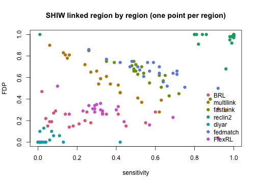

```r
colours <- grDevices::hcl.colors(length(methods), "Dark 3")
names(colours) <- methods
plot(NA, xlim = c(0, 1), ylim = c(0, 1), xlab = "sensitivity", ylab = "FDP",
     main = "SHIW linked region by region (one point per region)")
for (method in methods) {
  d <- results_IREG[results_IREG$method == method, ]
  points(d$sensitivity, d$FDP, col = colours[method], pch = 19)
}
legend("bottomright", legend = methods, col = colours, pch = 19, bty = "n")
```

The 5 PIVs have little discriminating power on these data and the two waves overlap on about 50% of their records (10.568 true links, 19.362 records in A, 20.016 records in B), so the task is hard for every package. `BRL`, `multilink`, `reclin2` and `diyar` are not scalable (out of memory errors).